# Text prediction: EDA and Markov Chain model

Jaime Leal

February 5, 2019

```r
library(dplyr)
library(quanteda)
library(data.table)
```

# 1 Introduction

The objective of the project is to create a model to predict text.

In this document we perform the exploratory data analysis of the English corpus. The we create a simple Markov Chain text prediciton model.

The data are text files of approximately 200 MB that contain sentences from 3 sources: blogs, newsites and Twitter posts.

# 2 Setup

## 2.1 Download datasets

```r
if(0){
  x <- "https://d396qusza40orc.cloudfront.net/dsscapstone/dataset/Coursera-SwiftKey.zip"
  download.file(x,"Coursera-SwiftKey.zip")
  unzip("Coursera-SwiftKey.zip")
}
```

## 2.2 Size of dataset

```r
n_lines_blogs <- R.utils::countLines("final/en_US/en_US.blogs.txt")
n_lines_news <- R.utils::countLines("final/en_US/en_US.news.txt")
n_lines_twitter <- R.utils::countLines("final/en_US/en_US.twitter.txt")
```

## 2.3 Read a sample

Because of speed considerations we will only read a fraction of the available texts.

```r
sample_size = 0.10 #fraction

blogs = readLines("final/en_US/en_US.blogs.txt",
                  n_lines_blogs * sample_size, encoding = "UTF-8",skipNul = T)

news = readLines("final/en_US/en_US.news.txt",
                 n_lines_news * sample_size, encoding = "UTF-8", skipNul = T)

twitter = readLines("final/en_US/en_US.twitter.txt",
                    n_lines_twitter * sample_size, encoding = "UTF-8", skipNul = T)

corpus_raw <- append(blogs, news)
corpus_raw <- append(corpus_raw,twitter)
```

```r
print(twitter[1:5])
```

```
## [1] "How are you? Btw thanks for the RT. You gonna be in DC anytime soon? Love to see you. Been way, way too long."
## [2] "When you meet someone special... you'll know. Your heart will beat more rapidly and you'll smile for no reason."
## [3] "they've decided its more fun if I don't."
## [4] "So Tired D; Played Lazer Tag & Ran A LOT D; Ughh Going To Sleep Like In 5 Minutes ;)"
## [5] "Words from a complete stranger! Made my birthday even better :)"
```

```r
print(news[1:2])
```

```
## [1] "He wasn't home alone, apparently."
## [2] "The St. Louis plant had to close. It would die of old age. Workers had been making cars there since the onset of mass automotive production in the 1920s."
```

```r
print(blogs[1:2])
```

```
## [1] "In the years thereafter, most of the Oil fields and platforms were named after pagan gods."
## [2] "We love you Mr. Brown."
```

# 3 Data cleaning

Things that we do for this step:

1. Convert to lower case
2. Normalize apostrophes
3. Remove all characters except letters in the alphabet.

Examples of things removed in this step are:

- Emoticons
- Symbols in other languages (like Chinese characters)
- Special symbols
4. Remove white spaces

Thigs that we don’t check for in this step but need to keep in mind:

- Misspellings
- Non words ie: “hmmmm”, “aaahh”, “hahaha”

```r
corpus_clean <- corpus_raw %>%
  sapply(enc2native, USE.NAMES = FALSE) %>%
  # Set everything to lower case
  sapply(tolower, USE.NAMES = FALSE) %>%
  # Remove everything, and only keep letters and apostrophe
  sapply(gsub, pattern = "[^a-zA-Z ']", replacement = "",USE.NAMES = FALSE) %>%
  # Remove apostrophe outside of words, and at the start and beginning of words
  sapply(gsub, pattern =  "\\B[']+\\B", replacement = "", USE.NAMES = FALSE) %>%
  sapply(gsub, pattern =  "\\B[']+\\b", replacement = "", USE.NAMES = FALSE) %>%
  sapply(gsub, pattern =  "\\b[']+\\B", replacement = "", USE.NAMES = FALSE) %>%
  # Long white spaces to short blank space
  sapply(gsub, pattern = "[ ]+", replacement = " ",USE.NAMES = FALSE) %>%
  # Remove leading/trailing whitespace
  sapply(trimws, "both", USE.NAMES = FALSE)

# Remove empty strings
corpus_clean <- corpus_clean[!sapply(corpus_clean, nchar)==0]
```

## 3.1 Remove profane words

In this step we remove the documents that have a profane word in it. For this task we use a list available in GitHub. We remove the complete document and not just the word because that way we don’t mess with the structure of the sentences of the remaining dataset.

```r
profane_words = read.csv({"https://raw.githubusercontent.com/LDNOOBW
  /List-of-Dirty-Naughty-Obscene-and-Otherwise-Bad-Words/master/en"},
  header = FALSE,stringsAsFactors = FALSE)[,1]

pw_total = 0

for(pw in seq_along(profane_words)){
  idxs = grepl(sprintf("\\<%s\\>",profane_words[pw]),corpus_clean)
  pw_total = pw_total + sum(idxs)
  corpus_clean = corpus_clean[!idxs]
}

print(sprintf("Documents removed for profanity : %d", pw_total))
```

```
## [1] "Documents removed for profanity : 11478"
```

# 4 Is the sample representative?

According to this [paper by Pastor and Seghiri](https://buleria.unileon.es/bitstream/handle/10612/4752/CorpasSeghiri.pdf?sequence=1), American English becomes representative with 150 documents and 350,000 words and British English with 180 documents and 600,000 words.

From the statistics below we can confirm that `corpus_clean` has enough documents and words to be considered representative for both language variants.

```r
word_count = sapply(corpus_clean, function(x){
  stringr::str_count(x,'\\w+')},
  USE.NAMES = F)

sprintf("Total number of documents: %d and total number of words: %d",length(corpus_clean), sum(word_count))
```

```
## [1] "Total number of documents: 391581 and total number of words: 9021667"
```

# 5 Exploration

## 5.1 Number of words in each document

```r
#Number of words in each string
print(summary(word_count))
```

```
##    Min. 1st Qu.  Median    Mean 3rd Qu.    Max.
##    1.00    8.00   15.00   23.04   26.00 1001.00
```

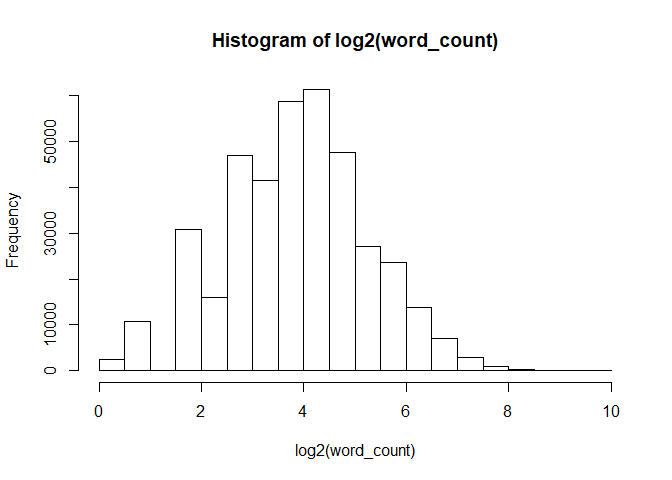

```r
hist(log2(word_count))
```

## 5.2 Word frequency

```r
feature_matrix <- dfm(corpus(corpus_clean))
text_frequency <- textstat_frequency(feature_matrix)
```

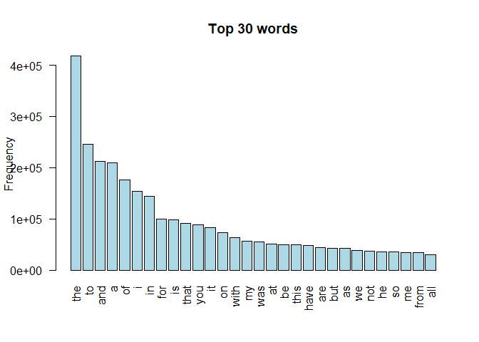

```r
top_n_words = 30

barplot(height=text_frequency$frequency[1:top_n_words],
        names.arg=text_frequency$feature[1:top_n_words],
        horiz=FALSE,
        las=2,
        main=sprintf("Top %d words",top_n_words),
        ylab = "Frequency",
        col = "lightblue")
```

## 5.3 Word frequency after removing stopwords

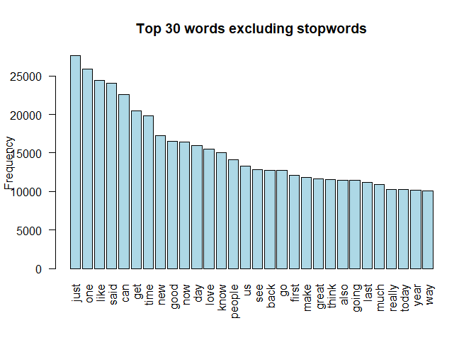

```r
text_frequency_nosw <- as.data.frame(text_frequency) %>% filter(!feature %in% stopwords())

barplot(height=text_frequency_nosw$frequency[1:top_n_words],
        names.arg=text_frequency_nosw$feature[1:top_n_words],
        horiz=FALSE,
        las=2,
        main= sprintf("Top %d words excluding stopwords",top_n_words),
        ylab = "Frequency",
        col = "lightblue")
```

## 5.4 N-grams frequency

```r
for( n in 2:3){
  top_n_words = 15
  feature_matrix_n_gram <- dfm(corpus(corpus_clean),remove  = stopwords(), ngrams=n)
  text_frequency_n_gram <- textstat_frequency(feature_matrix_n_gram)
  print(sprintf("Top %d %d-grams",top_n_words,n))
  print(as.data.frame(text_frequency_n_gram) %>% slice(1:top_n_words) %>% select(frequency, feature))
}
```

```
## [1] "Top 15 2-grams"
##    frequency  feature
## 1      37419   of_the
## 2      35927   in_the
## 3      19002   to_the
## 4      18133  for_the
## 5      17328   on_the
## 6      14567    to_be
## 7      12604   at_the
## 8      11058  and_the
## 9      10445     in_a
## 10      9173 with_the
## 11      9013     is_a
## 12      8722   it_was
## 13      8451    for_a
```

[output cut: 19 more lines]

## 5.5 How many unique words are needed to cover X% of all word instances in the language?

```r
text_frequency <- text_frequency %>%
  mutate(pct = frequency/sum(frequency)) %>%
  mutate(cumsum = cumsum(pct))
```

```r
for(x_frac in c(0.50,0.90)){
  nwords <- which(text_frequency$cumsum>x_frac)[1]/nrow(text_frequency)*100
  msg <-     sprintf("Only %.3f %% of the words are needed to cover %.0f %% of all the word instances.",nwords, x_frac*100)
  print(msg)
}
```

```
## [1] "Only 0.067 % of the words are needed to cover 50 % of all the word instances."
## [1] "Only 3.757 % of the words are needed to cover 90 % of all the word instances."
```

[figure not shown]

```r
plot(text_frequency$rank, text_frequency$cumsum * 100,
     type = "l",
     xlab = "Word rank",
     ylab = "Language coverage (%)",
     main = "Words needed to cover a percentage of all word instances")
abline(v = which(text_frequency$cumsum>0.50)[1],col = "blue")
abline(v = which(text_frequency$cumsum>0.90)[1], col = "red")
grid()
legend("bottomright", legend=c("50%", "90%"),
       col=c("blue", "red"), lty=1, cex=0.8,
       title="% Covered", text.font=4)
```

## 5.6 Words than only appear once

```r
print(sprintf("%.2f %% of the  words only appear one time", sum(text_frequency$frequency==1)/nrow(text_frequency)*100))
```

```
## [1] "59.00 % of the  words only appear one time"
```

# 6 Text prediction model

For the text prediction model we create a very simple Markov Chain model. This assumes that the probability of the next word only depends on the current word.[Wikipedia](https://en.wikipedia.org/wiki/Markov_property)

## 6.1 Function to calculate table of probabilities

```r
# Bigrams
feature_matrix_bigram <- dfm(corpus(corpus_clean), ngrams=2)
bigram_frequency <- textstat_frequency(feature_matrix_bigram)

bigram_table <- as.data.frame(bigram_frequency) %>%
  mutate(word1 = stringr::str_extract(feature,"^[a-z]+")) %>%
  mutate(word2 = stringr::str_extract(feature,"[a-z]+$")) %>%
  mutate(pct = frequency/sum(frequency)) %>%
  mutate(cumsum = cumsum(pct))


bigram_table = as.data.table(bigram_table)

get_table <- function(word,bigram_table){
  # To save space we only save the top 5 words
  DT = bigram_table[word1 ==word][1:5,]
  DT = DT[,prob := docfreq / sum(docfreq)]
  DT = DT[,.(word = word2,prob)]
  DT
}
```

```r
# Example of how the table looks like
print(get_table("hey", bigram_table))
```

```
##      word      prob
## 1:      i 0.4130926
## 2: thanks 0.1693002
## 3:    you 0.1444695
## 4:   guys 0.1399549
## 5:  there 0.1331828
```

## 6.2 Create Markov Chain

We create a table of probabilites for each word and store it in a list

```r
# To speed things we use only the bigrams needed to
# cover 50% of all bigrams instances
n_bigrams = which(bigram_table$cumsum>0.50)[1]

start.time <- Sys.time()
markov_chain = lapply(unique(bigram_table$word1)[1:n_bigrams], get_table,bigram_table)
end.time <- Sys.time()
time.taken <- end.time - start.time
time.taken
```

```
## Time difference of 1.62419 mins
```

```r
names(markov_chain) = unique(bigram_table$word1)[1:n_bigrams]
saveRDS(markov_chain,file = "markov_chain.rds")
```

## 6.3 Unigram frequency

We will use the unigram frequency for those cases were a word is not found in the bigram table.

```r
unigram_frequency  = text_frequency %>% select(feature,pct) %>% rename(word=feature,prob=pct)
```

## 6.4 Functions to predict text with Markov Chain

```r
get_next_word <- function(word, markov_chain){
  sample(x = markov_chain[[word]]$word,
         prob = markov_chain[[word]]$prob,
         size=1)

}


sample_most_popular <- function(unigram_frequency){

  sample(x = unigram_frequency$word,
         prob = unigram_frequency$prob,
         size=1)
}

predict_next_word <- function(last_word, markov_chain, unigram_frequency){
  # If word is not in Markov Chain return instead one of the most
  # popular words
  next_word <- tryCatch({
    return(get_next_word(last_word, markov_chain))
    },
    error = function(e){
      return(sample_most_popular(unigram_frequency))
    }
    )
  return(next_word)

}

generate_text <- function(text, markov_chain, unigram_frequency, n){

  text = as.character(text)
  tokens = strsplit(text,split = " ")[[1]]
  last_word = tokens[length(tokens)]

  if(length(last_word) == 0){
    last_word = sample_most_popular(unigram_frequency)
  }

  for(i in 1:n){
  next_word = predict_next_word(last_word, markov_chain, unigram_frequency)
  text = paste(text,next_word,sep = " ")
  last_word = next_word

  }

  text

}
```

## 6.5 Making predictions

```r
# The words are drawn from a probability distribution, so the prediction doesnt return the
# same word each time
print(generate_text("hey",markov_chain,unigram_frequency,2))
```

```
## [1] "hey thanks for"
```

```r
print(generate_text("hey",markov_chain,unigram_frequency,2))
```

```
## [1] "hey there were"
```

```r
print(generate_text("hey",markov_chain,unigram_frequency,2))
```

```
## [1] "hey guys are"
```

```r
# We can also use the functions to generate text without any seed word.
#The first word is drawn from the  most popular words table
print(generate_text("",markov_chain,unigram_frequency,30))
```

```
## [1] " to be a few years old school and i am i love to get the world to the most of the first place to be able to the best of"
```

```r
print(generate_text("",markov_chain,unigram_frequency,30))
```

```
## [1] " out there are the same thing to do the best of the first time i love that is the first and it is a lot more to get to get"
```

```r
print(generate_text("",markov_chain,unigram_frequency,30))
```

```
## [1] " you have the first time to get the best way to do you know how the best way to the first place and a lot of his own life and"
```

# 7 Next steps

There is much room for improving the text prediction model. For example, it is simplistic to assume that the next word only depends on the previous word. We can make a better prediction if we consider also the last 2 or 3 words together.